# AVANCE EN EL CIERRE DE BRECHAS

Autor: Alexander Gil Guzman

## I. Introducción

Asimismo, la información presentada y analizada en el informe permitirá a los tomadores de decisiones en materia de inversión pública, identificar hacia dónde dirigir, reforzar o reorientar sus intervenciones, en aras de lograr mayores avances en el cierre de las brechas que decanten en una mejor provisión de los servicios a la población del país.

## II. Programacion Multianual de inversiones 2024-2026 y su asociación al cierre de brechas

### 1.1. Validación Metodológica de los Indicadores de Brechas

**Indicadores de Brechas aprobados por Sector**

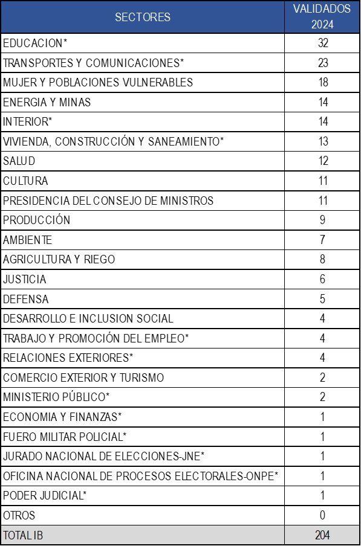

Fuente: Ministerio de Economía y Finanzas (MEF) - DGPMI.

### 1.2. Registro de valores numéricos

Luego de la validación Metodológica de los indicadores de brecha, se realiza la actualización de sus valores numéricos mediante registro en el MPMI. Todo ello de acuerdo con los plazos establecidos en el Anexo 06 de la Directiva General.

Al respecto, es importante señalar que los 204 indicadores de brechas aprobados, el 9.3% (19) no cuentan con registro alguno, los cuales pertenecen a los sectores Educación, Defensa, Presidencia del consejo de ministros, Agricultura y Mujer y Poblaciones Vulnerables. Asimismo, los indicadores que tienen registros representan 90.7% (185), siendo el 16.7% (34) con registro, pero no en el nivel óptimo y el 74% (151) los que tienen registros en el nivel óptimo.

**Registro de valores numéricos**

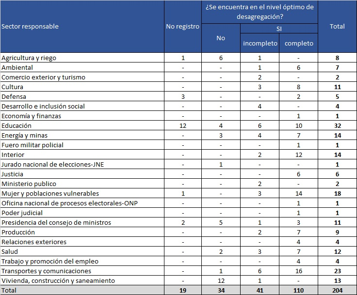

Fuente: Ministerio de Economía y Finanzas (MEF) - DGPMI.

### 1.3. Cartera de Inversiones 2024- 2026 del PMI alineada al cierre de brechas de infraestructura y de acceso servicios

La cartera de inversiones del PMI contiene la selección de las inversiones programadas para alcanzar las metas respecto al cierre de brechas prioritarias en cada territorio durante el periodo 2024-2026, tanto en infraestructura como en acceso a los servicios públicos. Este proceso está alineado a los objetivos nacionales, regionales y locales establecidos en el planeamiento estratégico y la asignación multianual de fondos públicos del proceso presupuestario. Así, la cartera de inversiones del PMI concreta de manera tangible la estrategia de cierre de brechas a través de la inversión pública de cada entidad, y, por ende, del país.

De acuerdo con la información de la cartera de inversiones al cierre del 2023, se tomará los indicadores de brechas con mayor monto devengado en el año 2023 y su respectivo número de inversiones.

#### Devengado 2023

En el siguiente gráfico presentamos las brechas que cuentan con mayor devengado:

**Devengado 2023 asociados a los indicadores de brechas** **(Monto en millones de soles)**

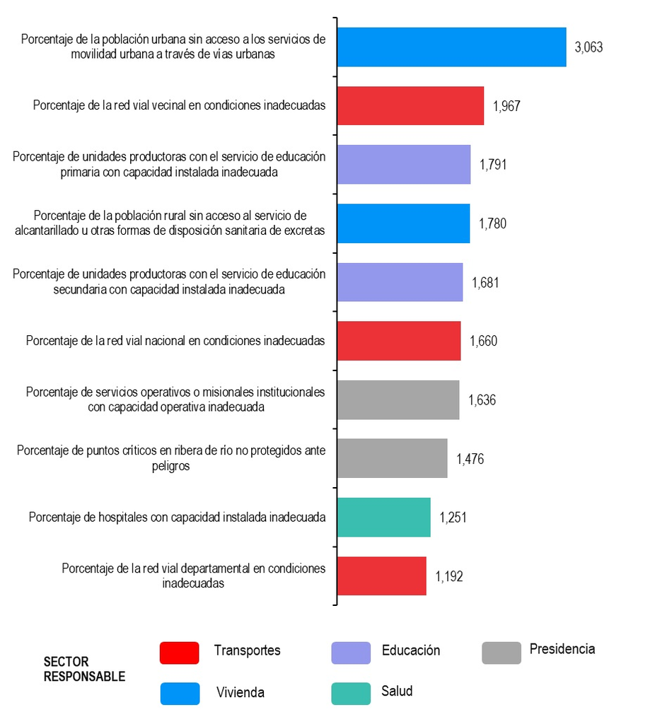

Fuente: Ministerio de Economía y Finanzas (MEF) - DGPMI.

#### Numero de Inversiones

El siguiente grafico presenta el número de inversiones:

**Numero de Inversiones asociados a los indicadores de brechas**

[figure not shown]

Fuente: Ministerio de Economía y Finanzas (MEF) - DGPMI.

En línea a los montos ejecutados, el mayor numero de inversiones corresponde al Sector Vivienda (3,563 inversiones en el indicador “porcentaje de la población urbana sin acceso a los servicios de movilidad urbana a través de vías urbanas”), seguido del indicador de “Porcentaje de la red vial vecinal en condiciones inadecuadas”, con 2,604 inversiones. Por otro lado, a diferencia del grafico anterior el indicador “Porcentaje de la población rural sin acceso al servicio de alcantarillado u otras formas de disposición sanitaria de excretas”, es el tercer indicador con mayor número de inversiones (2,267).

### 1.4. Inversiones cerradas

Al respecto, al inicio del año del 2023 se programó cerrar 3,395 inversiones, mucho mayor a las 2,076 inversiones que cerraron al final del 2023, siendo solo el 61% de la cantidad de inversiones que se programó a cerrar. Asimismo, si observamos el sector responsable de los servicios que se atienden con las inversiones, vemos un comportamiento similar entre la cantidad de inversiones programadas a cerrar de las que se cerraron efectivamente.

**Inversiones programadas a cerrar vs inversiones cerradas**

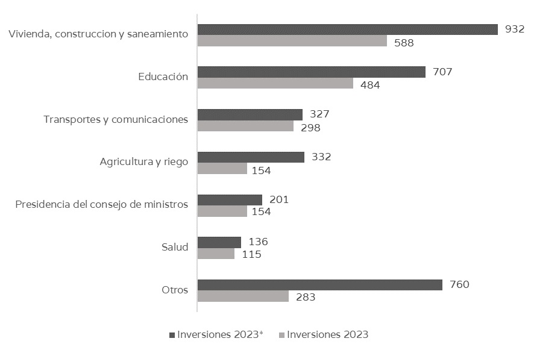

Fuente: Ministerio de Economía y Finanzas (MEF) - DGPMI.

## III. Principales brechas de infraestructura y acceso a servicios públicos, su cumplimiento de lo programado en el 2023.

### Transportes y Comunicaciones

En el sector Transportes y Comunicaciones, los indicadores relacionados al acceso a internet fijo y a sistemas integrados de transporte por implementar son los que presentan una mayor brecha, con 85,9% y 75,4%, respectivamente. Sin embargo, se puede notar que los indicadores que presentan menor brecha son los de cobertura de la red vial nacional y departamental, así como de aeródromos, con 6,4%, 14,3% y 8,1% respectivamente. Asimismo, con respecto al cumplimiento de lo programado a cerrar, tenemos que el mayor no cumplimiento del cierre de brecha se dio en el indicador “Porcentaje de la red de caminos de herradura no intervenidos”, con un -66,1% de brecha no cerrada.

**Brechas prioritarias y su cumplimiento al 2023**

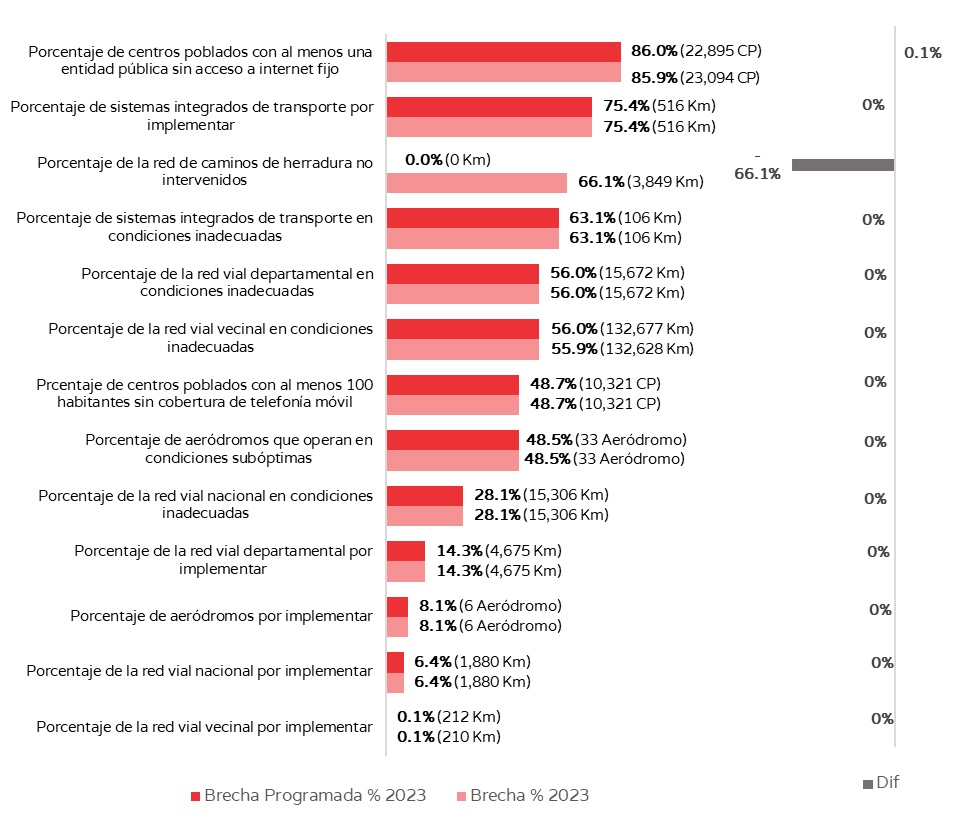

Fuente: Ministerio de Economía y Finanzas (MEF) - DGPMI.

### Educación

**Brechas prioritarias y su cumplimiento al 2023**

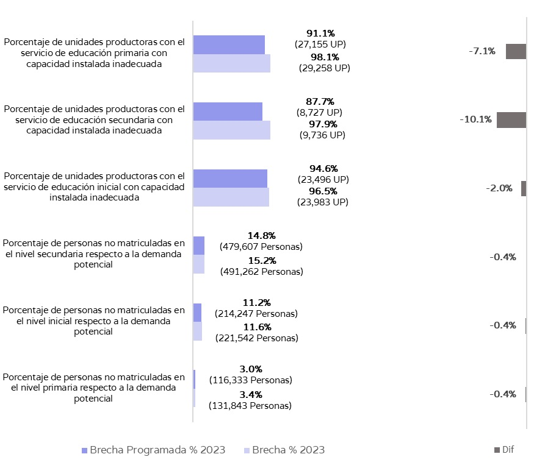

Fuente: Ministerio de Economía y Finanzas (MEF) - DGPMI.

### Salud

**Brechas prioritarias y su cumplimiento al 2023**

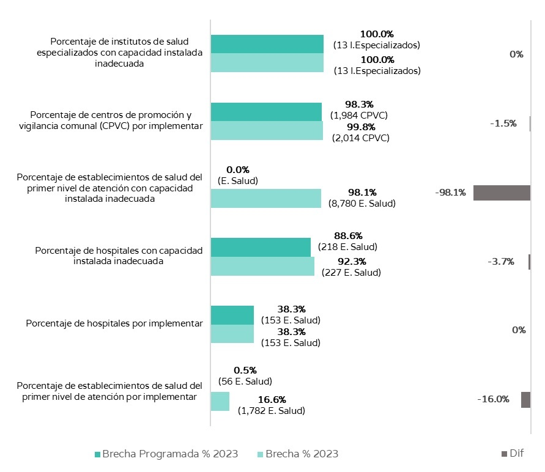

Fuente: Ministerio de Economía y Finanzas (MEF) - DGPMI.

### Vivienda Construcción y Saneamiento

En el sector Vivienda, Construcción y Saneamiento, los indicadores de cobertura relacionados al acceso al servicio de alcantarillado y espacios públicos verdes en zonas urbanas son los que tienen mayor brecha, con 66,8% y 39,0%, respectivamente. Es importante destacar que los indicadores de cobertura de acceso urbano al servicio de agua potable y alcantarillado presentan la menor brecha 7,5% y 13,3% respectivamente. Asimismo, con respecto al cumplimiento de lo programado a cerrar, tenemos que el mayor no cumplimiento del cierre de brecha se dio en el indicador “Porcentaje de la población urbana sin acceso a los servicios de movilidad urbana a través de vías urbanas”, con un -24,5% de brecha no cerrada.

**Brechas prioritarias y su cumplimiento al 2023**

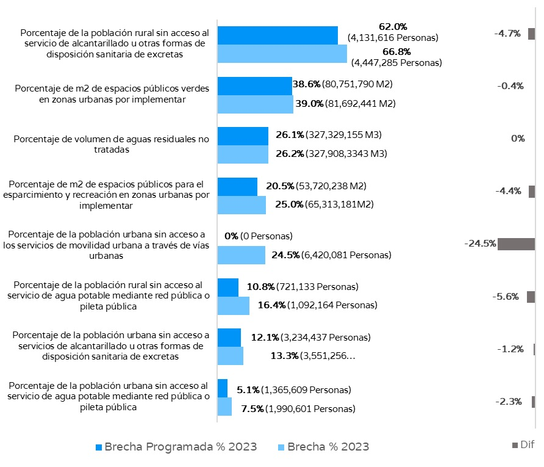

Fuente: Ministerio de Economía y Finanzas (MEF) - DGPMI.

### Agricultura y Riego

En el sector Agricultura y Riego, los indicadores relacionados con la superficie agrícola sin riego tecnificado y la superficie agrícola sin riego son los que presentan mayor brecha, con 87,4% y 78,6%, respectivamente. Mientras que en el caso del indicador de calidad de sistemas de riego que operan en condiciones inadecuadas se tiene 56,6%. Asimismo, con respecto al cumplimiento de lo programado a cerrar, tenemos que el mayor no cumplimiento del cierre de brecha se dio en el indicador “Porcentaje de sistemas de riego que operan en condiciones inadecuadas”, con un -22,7% de brecha no cerrada.

**Brechas prioritarias y su cumplimiento al 2023**

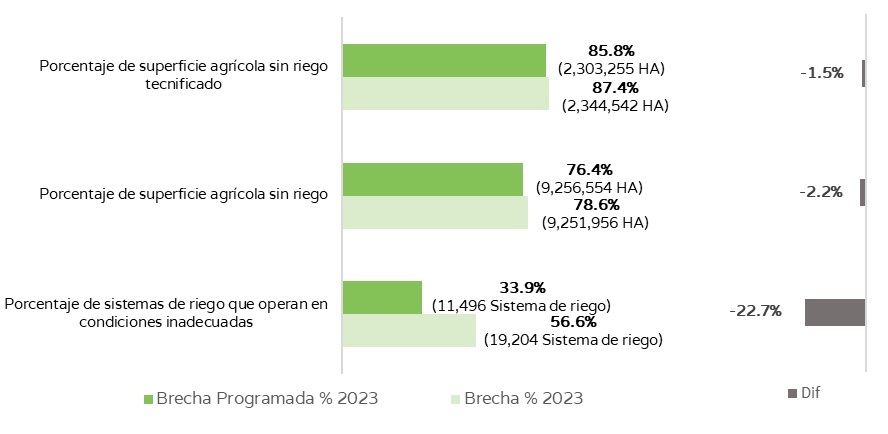

Fuente: Ministerio de Economía y Finanzas (MEF) - DGPMI.

### Energía y Minas

En el sector Energía y Minas, los indicadores relacionados con el servicio de distribución eléctrica con deficiencias y viviendas en el ámbito rural que no cuentan con servicio eléctrico son los que tienen mayor brecha con 75,7% y 15,2%, respectivamente. Por su parte, el indicador de viviendas en el ámbito urbano sin acceso al servicio de energía eléctrica, es el que presenta menor brecha (10,9%). Asimismo, con respecto al cumplimiento de lo programado a cerrar, tenemos que el mayor no cumplimiento del cierre de brecha se dio en el indicador “Porcentaje de viviendas en el ámbito rural que no cuentan con servicio eléctrico”, con un -1,5% de brecha no cerrada.

**Brechas prioritarias y su cumplimiento al 2023**

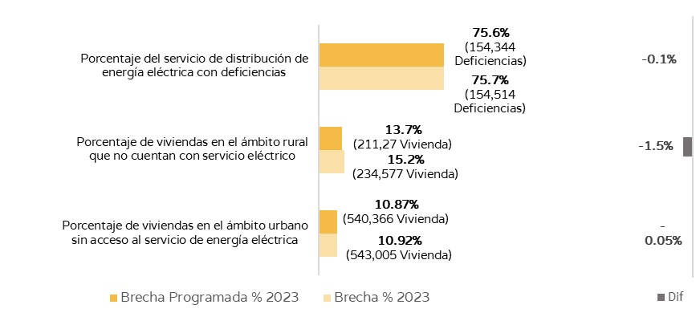

Fuente: Ministerio de Economía y Finanzas (MEF) - DGPMI.

### Producción

En el sector Producción, los indicadores de cobertura y calidad de mercados de abastos, así como el indicador de calidad de los desembarcaderos pesqueros artesanales, son los que tienen mayor brecha con 98,8%, 95,2% y 93,8%, respectivamente. Asimismo, con respecto al cumplimiento de lo programado a cerrar, tenemos que el mayor no cumplimiento del cierre de brecha se dio en el indicador “Porcentaje de mercados de abastos que operan en condiciones inadecuadas”, con un -98,8% de brecha no cerrada.

**Brechas prioritarias y su cumplimiento al 2023**

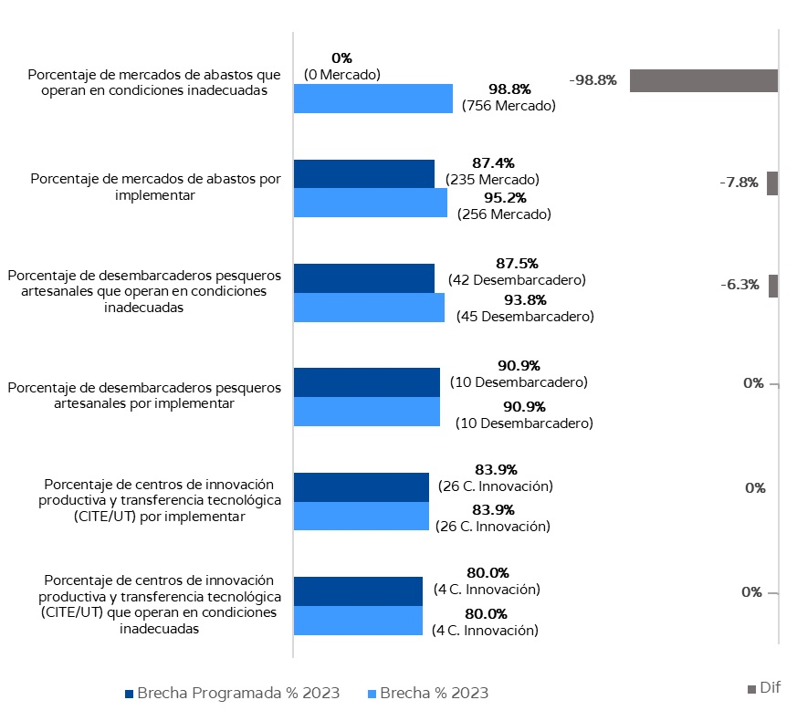

Fuente: Ministerio de Economía y Finanzas (MEF) - DGPMI.

### Interior

En el sector Interior, el indicador de calidad de comisarias básicas que operan en condiciones inadecuadas tiene la mayor brecha con 32,5%, mientras el indicador referido a la cobertura de dichas comisarías tiene una brecha reducida del 9,0%. Asimismo, con respecto al cumplimiento de lo programado a cerrar, tenemos que el mayor no cumplimiento del cierre de brecha se dio en el indicador “Porcentaje de comisarías básicas que operan en condiciones inadecuadas”, con un -6,7% de brecha no cerrada.

**Brechas prioritarias y su cumplimiento al 2023**

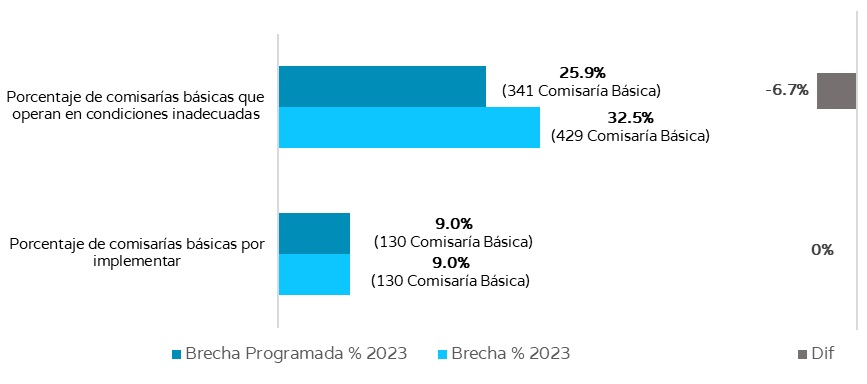

Fuente: Ministerio de Economía y Finanzas (MEF) - DGPMI.